# What explains the electoral success of the AfD?

May 1, 2016  
Hertie School of Governance

## Introduction

- Within less than three years of being founded, the **Alternative for Germany** (AfD) has achieved extraordinary vote share in the General election of 2013, and the European Parliament election of 2014 (Arzheimer 2015)
- March 2016: **15.1%** in Baden-WÃ¼rttemberg, **12.6%** in Rhineland-Palatinate, **24.3%** in Saxony-Anhalt
- "**a landslide**"(Pausch 2016)
- The AfD has **"arrived in German mainstream politics"** (Gathmann and Wittrock 2016)

## Existing Research

- AfD can be described as a "**functional equivalent for a right-wing populist party** in a country where right-wing politics are strongly stigmatised" (Berbuir, Lewandowsky, and Siri 2015)
- Ivarsflaten (2008) : Successful RRWP parties almost always use **anti-immigration rhethorics**
- Swank and Betz (2003) : **Volume of refugees**, level of **immigration**, domestic **tax burden**, and strong presence of **left-wing parties** positively influences right wing-populist electoral success
- AfD was especially successful in mobilizing former **non-voters** and the **unemployed** (Gathmann and Wittrock 2016)

## Research Question

*"What explains the recent electoral success of the AfD in the different districts of Baden-WÃ¼rttemberg, Rhineland-Palatinate, and Saxony-Anhalt?"*

- What structural factors correlate with the success
- Same factors as found for other western European countries?

## Election data

*Source: Baden-Wuerttemberg (2016), Rheinland-Pfalz (2016), Sachsen-Anhalt (2016)*

| Variable | Name in dataset | Description |
| --- | --- | --- |
| Dependent Variable (DV) | **vote.AfD** | The vote share of the Alternative for Germany in the current state election |
| Independent Variable 1 (IV1) | **lag.turnout** | Overall voter turnout of the previous state election |
| IV2, IV3, IV4, IV5, IV6 | **lag.CDU**, **lag.Greens**, **lag.SPD**, **lag.FDP**, **lag.Linke** | The vote share of political parties in the previous state election (CDU, SPD, Greens, FDP, and Linke) |

## Structural data

*Source: Bundesamt (2015)*

| Variable | Name in dataset | Description |
| --- | --- | --- |
| IV7 | **abitur.ratio** | Ratio of school leavers per district with general qualification for university entrance (Abitur) |
| IV8 | **nodegree.ratio** | Ratio of school leavers per district with no school degree |
| IV9 | **GDP.cap** | Gross domestic product (GDP) per capita |
| IV10 | **unemp.rate** | Unemployment rate in the district |
| IV11 | **n.refugees** | Number of asylum seekers per district |

## Distribution of AfD vote share

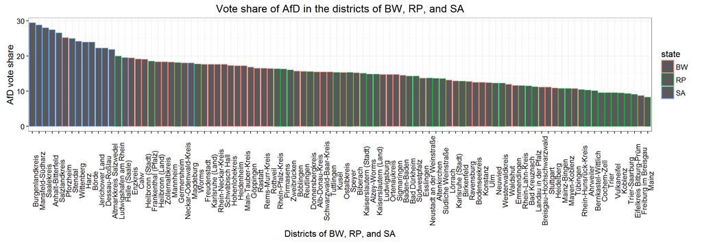

## The corelation of GDP per capita and AfD vote share

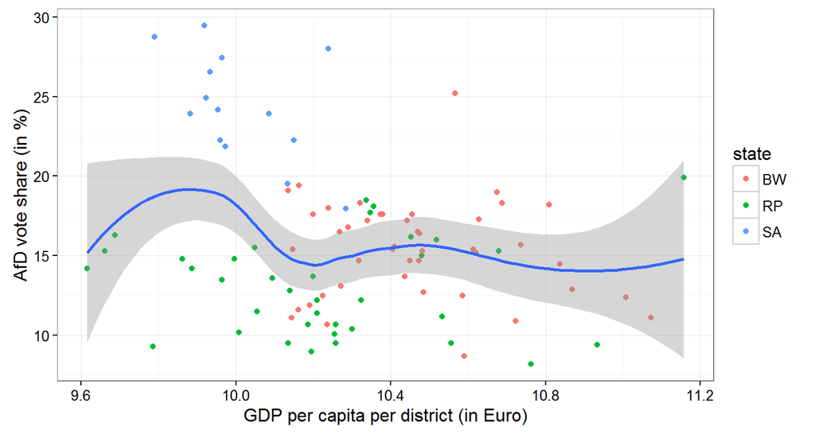

## The corelation of unemployment and AfD vote share

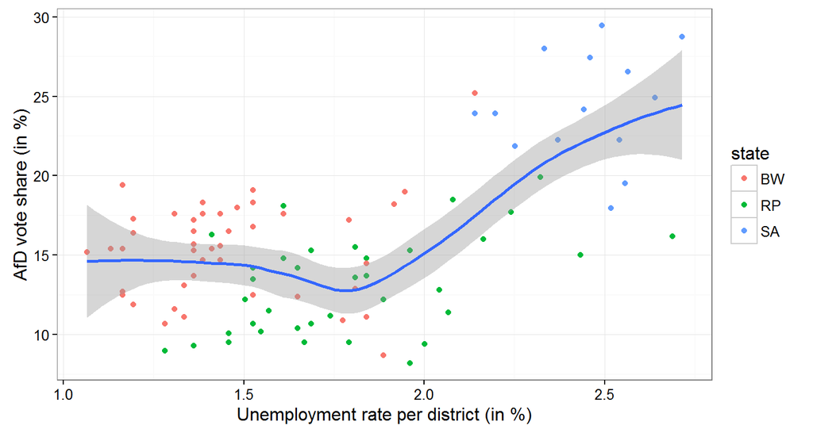

## The corelation of no. of refugees and AfD vote share

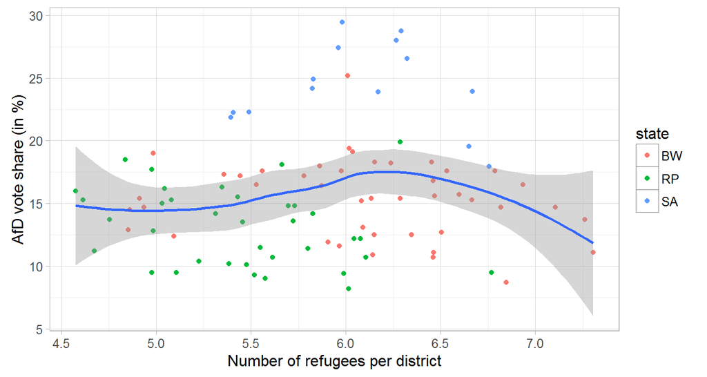

## Future research

- Analysis of all state elections in Germany where the AfD is present in order to have more observations
- Access more recent data on refugee numbers
- Additional variables, like "immigrants per district"
- Spatial analysis

## Q&A

**Thank you for your attention**

## References

Arzheimer, Kai. 2015. “The AfD: Finally a Successful Right-Wing Populist Eurosceptic Party for Germany?” *West European Politics* 38 (3). Taylor & Francis: 535–56.

Baden-Wuerttemberg, Statistisches Landesamt. 2016. “Wahl zum 16. Landtag von Baden-Wuerttemberg am 13. Maerz 2016.” http://www.statistik.baden-wuerttemberg.de/Wahlen/Landtag/.

Berbuir, Nicole, Marcel Lewandowsky, and Jasmin Siri. 2015. “The AfD and Its Sympathisers: Finally a Right-Wing Populist Movement in Germany?” *German Politics* 24 (2). Taylor & Francis: 154–78.

Bundesamt, Statistisches. 2015. “Zahlen & Fakten.” https://www.destatis.de/DE/ZahlenFakten/ZahlenFakten.html.

Gathmann, Florian, and Philipp Wittrock. 2016. “Blitzanalyse Zu Den Landtagswahlen: AfD Triumphiert, Schwarzer Sonntag Fuer Die CDU.” Edited by spiegel.de. http://www.spiegel.de/politik/deutschland/landtagswahlen-2016-in-der-blitzanalyse-afd-triumph-cdu-debakel-a-1082090.html.

Ivarsflaten, Elisabeth. 2008. “What Unites Right-Wing Populists in Western Europe? Re-Examining Grievance Mobilization Models in Seven Successful Cases.” *Comparative Political Studies* 41 (1). Sage Publications: 3–23.

Pausch, Robert. 2016. “Partei Der Radikalisierten Mitte.” Edited by zeit.de. http://www.zeit.de/politik/deutschland/2016-03/afd-analyse-erfolg-landtagswahlen-partei-waehler.

Rheinland-Pfalz, Statistisches Landesamt. 2016. “Landtagswahl 2016.” https://www.statistik.rlp.de/gesellschaft-und-staat/wahlen/analysen/landtagswahlen/.

Sachsen-Anhalt, Statistisches Landesamt. 2016. “Landtagswahl 2016.” http://www.statistik.sachsen-anhalt.de/wahlen/lt16/index.html.

Swank, Duane, and Hans-Georg Betz. 2003. “Globalization, the Welfare State and Right-Wing Populism in Western Europe.” *Socio-Economic Review* 1 (2). SASE: 215–45.